# **FoodHub Data Analysis Project**

## Project Overview

The number of restaurants in New York is increasing day by day, and lots of students and busy professionals rely on these restaurants due to their hectic lifestyles. Food aggregators like FoodHub offer access to multiple restaurants through a single smartphone app, helping customers order food easily online.

This project analyzes data from FoodHub to find trends and patterns in food orders. By answering key business questions, this analysis helps FoodHub improve customer experience and business strategy.

## Objectives

- Understand the structure of the FoodHub order dataset
- Explore the data using summary statistics and visualizations
- Identify trends in restaurant and cuisine popularity
- Analyze customer ratings and delivery/performance times
- Provide recommendations for FoodHub to enhance business operations
1. Introduction to Python Project : FoodHub Data Analysis
2. Problem Statement
3. Data Dictionary
4. Importing Required Libraries
5. Understanding the Structure of the Data
6. Univariate Data Analysis
7. Multivariate Data Analysis
8. Quality & Use of Visualizations
9. Conclusion and Recommendations
10. Overall Notebook Quality
11. Q&A for FoodHub Data Analysis

# **1. Understanding the Structure of the Data**

## Data Description

The dataset contains the following columns:

| Column Name | Description |
| --- | --- |
| order_id | Unique ID for each order |
| customer_id | Unique ID for each customer |
| restaurant_name | Name of the restaurant |
| cuisine_type | Type of cuisine ordered |
| cost_of_the_order | Cost of the order |
| day_of_the_week | Indicates whether it's a weekday or a weekend order |
| rating | Customer rating (out of 5) |
| food_preparation_time | Time taken (in minutes) to prepare the food |
| delivery_time | Time taken (in minutes) to deliver the food |

## **Explanation:**

```python
from google.colab import files
uploaded = files.upload()
```

Upload widget is only available when the cell has been executed in the current browser session. Please rerun this cell to enable.

```
Saving foodhub_order.csv to foodhub_order (1).csv
```

```python
import pandas as pd

import numpy as np

import seaborn as sns

import matplotlib.pyplot as plt

sns.set(style="whitegrid")
plt.rcParams["figure.figsize"] = (10, 6)
```

```python
df = pd.read_csv('foodhub_order.csv')
```

```python
df.head()
```

|  | order_id | customer_id | restaurant_name | cuisine_type | cost_of_the_order | day_of_the_week | rating | food_preparation_time | delivery_time |
| --- | --- | --- | --- | --- | --- | --- | --- | --- | --- |
| 0 | 1477147 | 337525 | Hangawi | Korean | 30.75 | Weekend | Not given | 25 | 20 |
| 1 | 1477685 | 358141 | Blue Ribbon Sushi Izakaya | Japanese | 12.08 | Weekend | Not given | 25 | 23 |
| 2 | 1477070 | 66393 | Cafe Habana | Mexican | 12.23 | Weekday | 5 | 23 | 28 |
| 3 | 1477334 | 106968 | Blue Ribbon Fried Chicken | American | 29.20 | Weekend | 3 | 25 | 15 |
| 4 | 1478249 | 76942 | Dirty Bird to Go | American | 11.59 | Weekday | 4 | 25 | 24 |

```python
print(f"Rows: {df.shape[0]}")
print(f"Columns: {df.shape[1]}")
```

```
Rows: 1898
Columns: 9
```

```python
df.info()
```

```
<class 'pandas.core.frame.DataFrame'>
RangeIndex: 1898 entries, 0 to 1897
Data columns (total 9 columns):
 #   Column                 Non-Null Count  Dtype
---  ------                 --------------  -----
 0   order_id               1898 non-null   int64
 1   customer_id            1898 non-null   int64
 2   restaurant_name        1898 non-null   object
 3   cuisine_type           1898 non-null   object
 4   cost_of_the_order      1898 non-null   float64
 5   day_of_the_week        1898 non-null   object
 6   rating                 1898 non-null   object
 7   food_preparation_time  1898 non-null   int64
 8   delivery_time          1898 non-null   int64
dtypes: float64(1), int64(4), object(4)
memory usage: 133.6+ KB
```

All columns have appropriate data types (integer, float, or object for text). There are 1,898 rows (orders) and 9 columns in the dataset.

```python
df.describe()
```

|  | order_id | customer_id | cost_of_the_order | food_preparation_time | delivery_time |
| --- | --- | --- | --- | --- | --- |
| count | 1.898000e+03 | 1898.000000 | 1898.000000 | 1898.000000 | 1898.000000 |
| mean | 1.477496e+06 | 171168.478398 | 16.498851 | 27.371970 | 24.161749 |
| std | 5.480497e+02 | 113698.139743 | 7.483812 | 4.632481 | 4.972637 |
| min | 1.476547e+06 | 1311.000000 | 4.470000 | 20.000000 | 15.000000 |
| 25% | 1.477021e+06 | 77787.750000 | 12.080000 | 23.000000 | 20.000000 |
| 50% | 1.477496e+06 | 128600.000000 | 14.140000 | 27.000000 | 25.000000 |
| 75% | 1.477970e+06 | 270525.000000 | 22.297500 | 31.000000 | 28.000000 |
| max | 1.478444e+06 | 405334.000000 | 35.410000 | 35.000000 | 33.000000 |

```python
df.isnull().sum()
```

|  | 0 |
| --- | --- |
| order_id | 0 |
| customer_id | 0 |
| restaurant_name | 0 |
| cuisine_type | 0 |
| cost_of_the_order | 0 |
| day_of_the_week | 0 |
| rating | 0 |
| food_preparation_time | 0 |
| delivery_time | 0 |

**dtype:** int64

There are no missing values in any of the columns. No data imputation or cleaning for missing data is required at this stage.

## **Summary for Section 1:**

- The FoodHub dataset is clean, with no missing values and correct data types.
- Each row is a unique order, covering important variables for business analysis such as customer, order value, timing, and ratings.
- The dataset is ready for further univariate and multivariate analysis.

# **2. Univariate Data Analysis**

## 2.1 Overview

In this section, each variable in the FoodHub dataset is explored individually using visualizations and summary statistics. The goal is to understand the distribution, central tendency, and key patterns for all major numerical and categorical variables.

## 2.2 Numerical Variables

## a) Cost of the Order

- Visualized using a histogram and described with summary statistics (`mean`, `median`, `std`, `min`, `max`).
- Title should read: Distribution of Cost of Order
- Axes should be clearly labeled (“Cost ($)” and “Number of Orders”).
- Markdown summary should mention if the data is right-skewed (longer tail to the right), left-skewed, or symmetrical, and note any outliers or typical range for most orders..

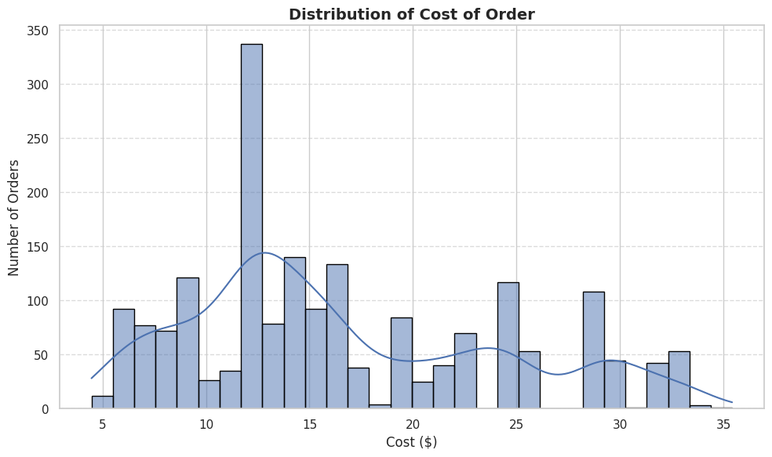

```python
plt.figure(figsize=(10, 6))
sns.histplot(df["cost_of_the_order"], bins=30, kde=True, color="#4C72B0", edgecolor='black')
plt.title("Distribution of Cost of Order", fontsize=14, fontweight='bold')
plt.xlabel("Cost ($)", fontsize=12)
plt.ylabel("Number of Orders", fontsize=12)
plt.grid(axis='y', linestyle='--', alpha=0.7)
plt.tight_layout()
plt.show()
```

```python
df["cost_of_the_order"].describe()
```

|  | cost_of_the_order |
| --- | --- |
| count | 1898.000000 |
| mean | 16.498851 |
| std | 7.483812 |
| min | 4.470000 |
| 25% | 12.080000 |
| 50% | 14.140000 |
| 75% | 22.297500 |
| max | 35.410000 |

**dtype:** float64

## Observation:

- The majority of food orders fall between $10 and $25.
- The histogram is slightly right-skewed, meaning a few customers spend more (₹30+) than most.
- The average (mean) cost of an order is about $16.5, with most customers spending between $12 (25%) and $22 (75%).
- The cheapest order was only $4.47, and the most expensive was $35.41.
- The standard deviation of $7.48 shows there’s some variety in spending, but it’s not extreme.

## b) Distribution of Customer Ratings

We’re looking at the ratings given by customers for their orders. This analysis will show the overall customer satisfaction, the frequency of high vs. low ratings, and will also highlight if many customers choose not to rate their orders.

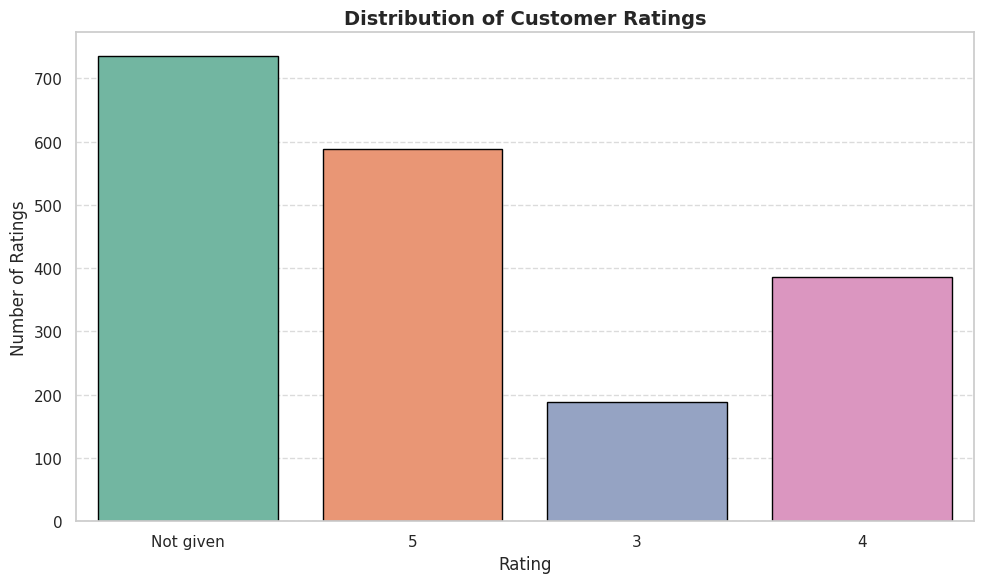

```python
plt.figure(figsize=(10, 6))
df["dummy_hue"] = df["rating"]
sns.countplot(x="rating", hue="dummy_hue", data=df, palette="Set2", edgecolor='black', legend=False)
plt.title("Distribution of Customer Ratings", fontsize=14, fontweight='bold')
plt.xlabel("Rating", fontsize=12)
plt.ylabel("Number of Ratings", fontsize=12)
plt.grid(axis='y', linestyle='--', alpha=0.7)
plt.tight_layout()
plt.show()
df.drop("dummy_hue", axis=1, inplace=True)
```

### Observation:

- A large number of customers did not give any rating ("Not given").
- Among those who did, most customers gave a 5-star rating, which shows high satisfaction.
- Very few people gave low ratings like 3 or below, suggesting that food and service are generally appreciated.
- However, the lack of feedback is significant and may limit the company’s ability to learn from customer experiences.

## c) Food Orders: Weekdays vs Weekends

We compare how many orders are placed during weekdays versus weekends. This information can help FoodHub optimize operations, staffing, and marketing efforts based on customer demand patterns across the week.

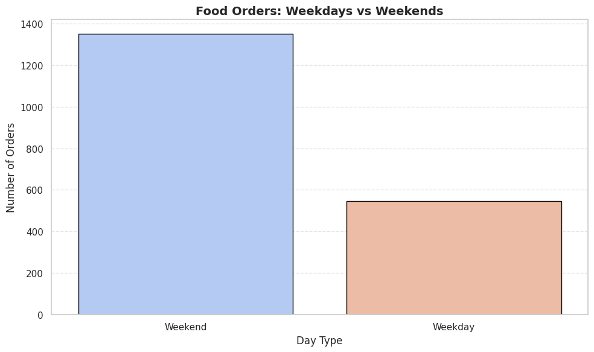

```python
plt.figure(figsize=(10, 6))
sns.countplot(x="day_of_the_week", hue="day_of_the_week", data=df,
              palette="coolwarm", edgecolor="black", legend=False)
plt.title("Food Orders: Weekdays vs Weekends", fontsize=14, fontweight="bold")
plt.xlabel("Day Type", fontsize=12)
plt.ylabel("Number of Orders", fontsize=12)
plt.grid(axis='y', linestyle='--', alpha=0.5)
plt.tight_layout()
plt.show()
```

## d) Top Cuisine Types Ordered

This plot examines which types of cuisines are ordered the most. It helps us understand customer food preferences and can highlight areas for expanding menu offerings or focusing marketing strategies.

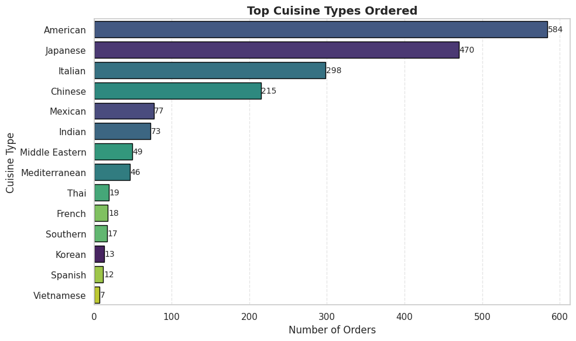

```python
plt.figure(figsize=(10, 6))
sns.countplot(
    y="cuisine_type",
    data=df,
    order=df["cuisine_type"].value_counts().index,
    hue="cuisine_type",
    palette="viridis",
    edgecolor="black",
    legend=False
)

plt.title("Top Cuisine Types Ordered", fontsize=14, fontweight='bold')
plt.xlabel("Number of Orders", fontsize=12)
plt.ylabel("Cuisine Type", fontsize=12)
plt.grid(axis="x", linestyle="--", alpha=0.5)

for index, value in enumerate(df["cuisine_type"].value_counts()):
    plt.text(value + 0.5, index, str(value), va='center', fontsize=10)

plt.tight_layout()
plt.show()
```

## Observation:

- American cuisine is the most frequently ordered food, indicating its high popularity among customers.
- Japanese, Italian, and Chinese cuisines are also highly preferred.
- Less popular cuisines include Vietnamese, Spanish, and Korean, which may be niche choices or have limited availability.

## e) Top 10 Most Ordered Restaurants

We identify the 10 most popular restaurants by order volume. This helps us see which restaurants attract the most customers on FoodHub and could guide business partnerships or promotions.

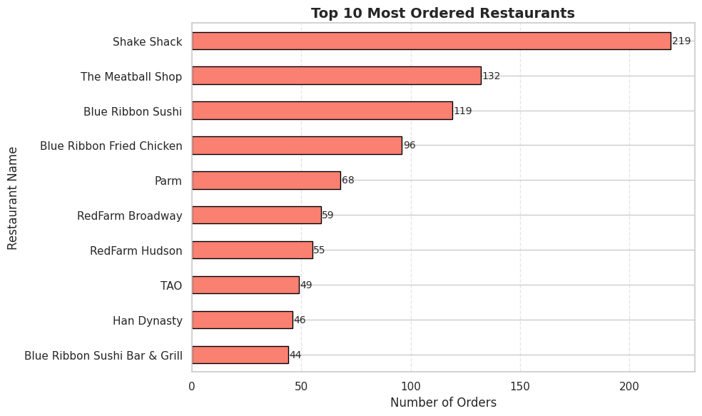

```python
plt.figure(figsize=(10, 6))

top_restaurants = df["restaurant_name"].value_counts().head(10)

top_restaurants.sort_values().plot(
    kind="barh",
    color="salmon",
    edgecolor="black"
)

plt.title("Top 10 Most Ordered Restaurants", fontsize=14, fontweight='bold')
plt.xlabel("Number of Orders", fontsize=12)
plt.ylabel("Restaurant Name", fontsize=12)
plt.grid(axis='x', linestyle='--', alpha=0.5)

# Add count labels on bars
for index, value in enumerate(top_restaurants.sort_values()):
    plt.text(value + 0.5, index, str(value), va='center', fontsize=10)

plt.tight_layout()
plt.show()
```

## Observation:

- Shake Shack is the most popular restaurant based on the number of food orders.
- Other highly ordered restaurants include The Meatball Shop, Blue Ribbon Sushi, and Blue Ribbon Fried Chicken.

## f) Distribution of Food Preparation Time (minutes)

We analyze how much time restaurants take to prepare the food. By exploring the distribution of preparation times, we can understand the typical speed of service and whether there are consistent outliers or most orders fall within a certain time frame.

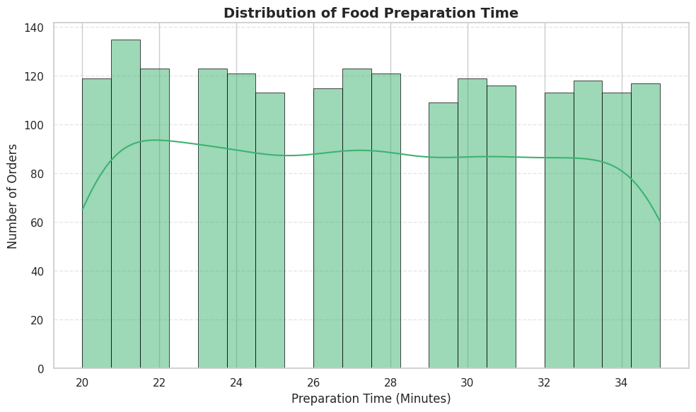

```python
plt.figure(figsize=(10, 6))

sns.histplot(
    df["food_preparation_time"],
    bins=20,
    kde=True,
    color="mediumseagreen",
    edgecolor="black",
    linewidth=0.5
)

plt.title("Distribution of Food Preparation Time", fontsize=14, fontweight='bold')
plt.xlabel("Preparation Time (Minutes)", fontsize=12)
plt.ylabel("Number of Orders", fontsize=12)
plt.grid(axis='y', linestyle='--', alpha=0.5)

plt.tight_layout()
plt.show()
```

## g) Distribution of Delivery Time (minutes)

This plot helps us understand how long it usually takes for customers to receive their orders from the time they leave the restaurant. Analyzing the spread and center of delivery times allows us to see if they are reliable and whether there are any unusually fast or slow deliveries.

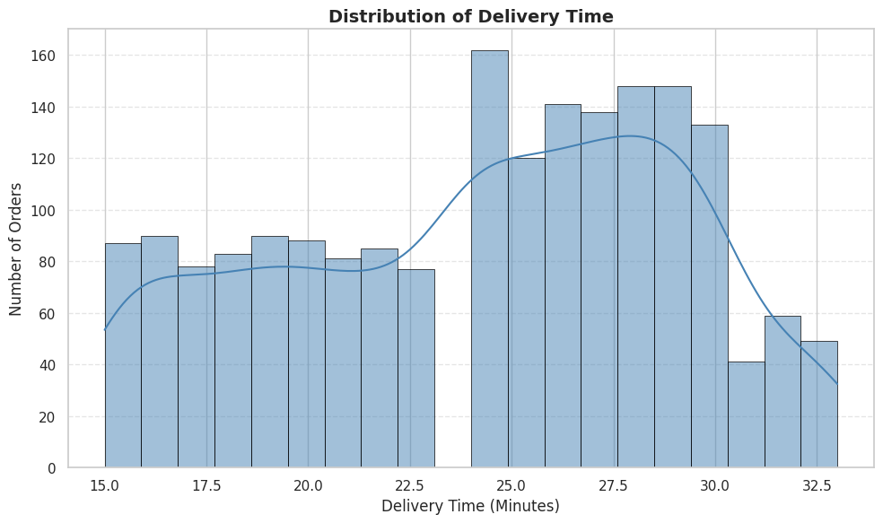

```python
plt.figure(figsize=(10, 6))

sns.histplot(
    df["delivery_time"],
    bins=20,
    kde=True,
    color="steelblue",
    edgecolor="black",
    linewidth=0.5
)

plt.title("Distribution of Delivery Time", fontsize=14, fontweight='bold')
plt.xlabel("Delivery Time (Minutes)", fontsize=12)
plt.ylabel("Number of Orders", fontsize=12)
plt.grid(axis='y', linestyle='--', alpha=0.5)

plt.tight_layout()
plt.show()
```

## **Observation:**

- Most food deliveries take between 20 and 30 minutes.
- The average delivery time is around 24 minutes, with a peak near 26–27 minutes.
- There are a few slower deliveries, but overall, the time is quite consistent.
- Restaurants or delivery partners could explore why some deliveries are above 30 minutes and whether those can be improved.

## Section 2 Summary: Key Univariate Insights

These insights provide an initial understanding of customer behavior and operational performance on the FoodHub platform. The next section will explore how these variables relate to each other (multivariate analysis).

# **3. Multivariate Data Analysis**

## 3.1 Overview

In this section, we examine pairwise (bivariate) and multi-variable relationships within the FoodHub data, using visualizations and summary bullet points.

## 3.2 Bivariate Analysis

## a) Comparison of Average Order Cost: Weekdays vs. Weekends

This analysis examines whether customers tend to spend more on food orders during weekends compared to weekdays. By comparing the average cost of orders for each period, we aim to understand if purchasing behavior shifts with the day of the week, which could inform promotions, resource allocation, and menu strategies.

```python
df.groupby("day_of_the_week")["cost_of_the_order"].mean()
```

| day_of_the_week | cost_of_the_order |
| --- | --- |
| Weekday | 16.311188 |
| Weekend | 16.574833 |

**dtype:** float64

## Observations:

On average, orders placed on weekends are slightly more expensive ($16.57) compared to weekdays ($16.31).

The difference is ~$0.26, which may indicate:

- More leisurely or bulk purchases on weekends.
- Promotions or discounts affecting weekday behavior.
- Slight customer behavior shift based on free time.

## b) Relationship Between Food Preparation Time and Customer Rating

This plot investigates whether the amount of time taken by a restaurant to prepare food influences the customer’s rating. We look for patterns or trends indicating if longer or shorter preparation times affect overall customer satisfaction as reflected in their ratings.

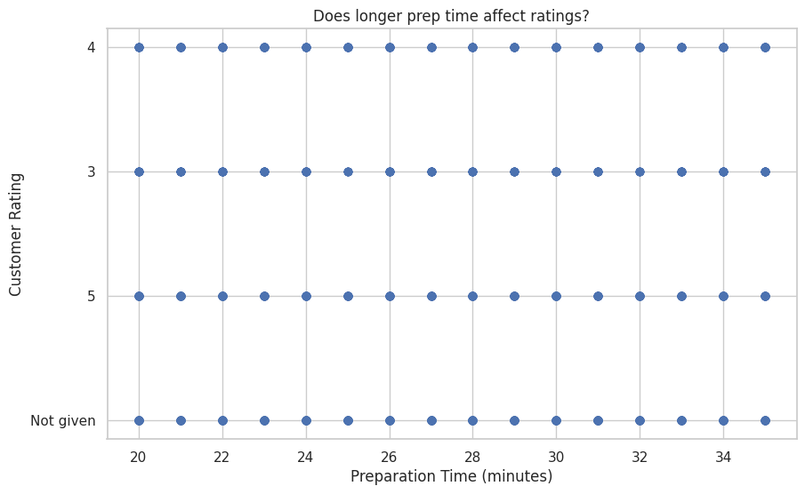

```python
import matplotlib.pyplot as plt

plt.figure(figsize=(10, 6))
plt.scatter(df["food_preparation_time"], df["rating"])
plt.xlabel("Preparation Time (minutes)")
plt.ylabel("Customer Rating")
plt.title("Does longer prep time affect ratings?")
plt.show()
```

## Observations:

From the plot:

- Ratings seem to be mostly clustered at 3, 4, and 5 stars, regardless of how long the food took to prepare.
- The food preparation time ranges from ~20 to 35 minutes, but the rating doesn't clearly go up or down based on it.
- This suggests: There is no strong correlation between how long the food takes to prepare and the rating customers give.

## c) Average Delivery Time by Cuisine Type

This analysis compares the average delivery times across different cuisine types. By examining which cuisines tend to have faster or slower delivery, we can identify operational or logistical challenges that may be associated with preparing and delivering certain food types. This information helps FoodHub and its partner restaurants optimize processes and improve customer satisfaction for specific cuisines.

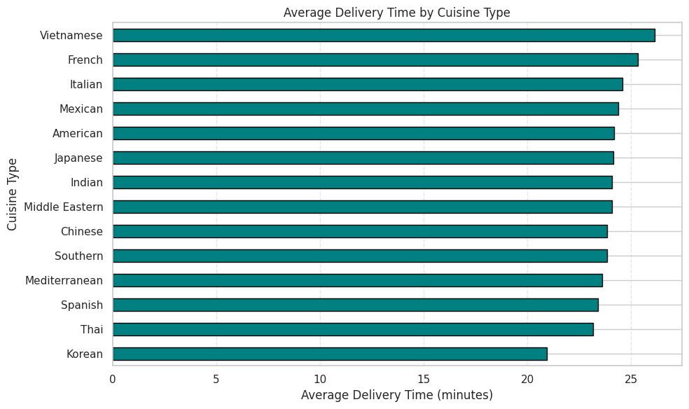

```python
import matplotlib.pyplot as plt

avg_delivery_time = df.groupby("cuisine_type")["delivery_time"].mean().sort_values()

plt.figure(figsize=(10, 6))
avg_delivery_time.plot(kind="barh", color="teal", edgecolor="black")
plt.xlabel("Average Delivery Time (minutes)")
plt.ylabel("Cuisine Type")
plt.title("Average Delivery Time by Cuisine Type")
plt.grid(axis='x', linestyle='--', alpha=0.5)
plt.tight_layout()
plt.show()
```

## Observations:

- Fastest delivered cuisine: Korean food average ~21 minutes.
- Slowest delivered cuisine: Vietnamese food average ~26 minutes.
- Most cuisines fall between 23–25 minutes, which means delivery times are fairly consistent overall.
- Korean and Thai food tend to be delivered fastest, while Vietnamese and French take a bit longer. This could be due to preparation complexity, restaurant location, or demand.

## d) Top 10 Restaurants by Average Customer Rating

This chart compares the average customer ratings for the top 10 restaurants on the platform. By ranking restaurants based on their average ratings, we can identify which restaurants consistently deliver high customer satisfaction and set benchmarks for service quality on FoodHub.

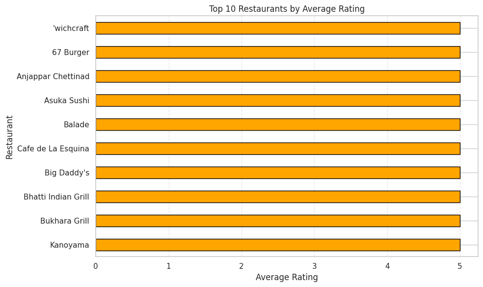

```python
import matplotlib.pyplot as plt

df["rating"] = pd.to_numeric(df["rating"], errors="coerce")

avg_rating_per_restaurant = df.groupby("restaurant_name")["rating"].mean().sort_values(ascending=False)

plt.figure(figsize=(10, 6))
avg_rating_per_restaurant.head(10).plot(kind="barh", color="orange", edgecolor="black")
plt.xlabel("Average Rating")
plt.ylabel("Restaurant")
plt.title("Top 10 Restaurants by Average Rating")
plt.gca().invert_yaxis()
plt.grid(axis='x', linestyle='--', alpha=0.5)
plt.tight_layout()
plt.show()
```

## Observation:

- Some restaurants such as 'wichcraft, 67 Burger, and Anjappar Chettinad have an average rating of 5.0, which is the maximum possible.
- Several restaurants show a rating of NaN, which likely means there were no ratings submitted by users for those outlets.
- Many top-rated restaurants may have received only one or two reviews, which could skew the average and doesn't always indicate overall quality.

## e) Relationship Between Order Cost and Customer Rating

This scatter plot examines if there is a relationship between how much a customer spends on an order and the rating they provide. By plotting individual order costs against their customer ratings, we can see whether higher costs tend to receive better ratings, or if customer satisfaction does not depend on order value.

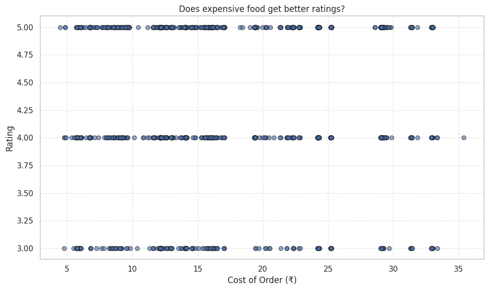

```python
plt.figure(figsize=(10, 6))
plt.scatter(df["cost_of_the_order"], df["rating"], alpha=0.6, edgecolors="k")
plt.xlabel("Cost of Order (₹)")
plt.ylabel("Rating")
plt.title("Does expensive food get better ratings?")
plt.grid(True, linestyle="--", alpha=0.5)
plt.tight_layout()
plt.show()
```

## Observation:

- The scatter plot shows no strong or clear correlation between the cost of the order and the rating received.
- Ratings are mostly concentrated at fixed values — specifically around 3.0, 4.0, and 5.0, regardless of whether the order was cheap or expensive.
- Higher-cost orders ($25–$35) still receive a mix of low (3), medium (4), and high (5) ratings — just like lower-cost orders ($5–$15).
- There are no significant outliers or strong patterns suggesting that more expensive orders are rated better.

## f) Correlation Heatmap Between Key Numerical Variables

This heatmap displays the pairwise correlations between the main numerical variables: cost of the order, customer rating, food preparation time, and delivery time. By examining the strength and direction of these correlations, we can identify whether any of these factors are strongly related, such as if higher costs tend to come with higher ratings or if longer preparation times are linked to longer deliveries. This analysis helps reveal which metrics operate independently and which may influence one another.

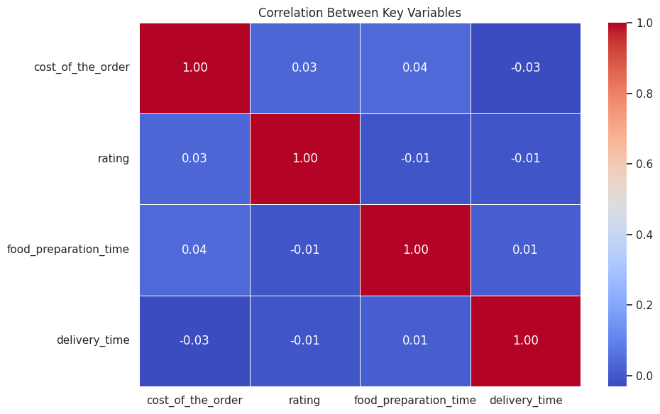

```python
import seaborn as sns
import matplotlib.pyplot as plt

# Select relevant numerical columns
num_df = df[["cost_of_the_order", "rating", "food_preparation_time", "delivery_time"]]

# Create the correlation heatmap
plt.figure(figsize=(10, 6))
sns.heatmap(num_df.corr(), annot=True, cmap="coolwarm", linewidths=0.5, fmt=".2f")
plt.title("Correlation Between Key Variables")
plt.tight_layout()
plt.show()
```

## **Observation:**

- There is no strong correlation among the numeric variables: Cost, Rating, Preparation Time, and Delivery Time. Here's a breakdown of each relationship:
- Cost vs. Rating: The correlation is very low and positive (+0.034), which means spending more does not lead to better customer ratings.
- Cost vs. Preparation Time: A negligible positive correlation (+0.042) suggests that higher-cost orders might take slightly more time to prepare, but the relationship is very weak.
- Cost vs. Delivery Time: There's a very weak negative correlation (–0.030), meaning cost has almost no effect on delivery time.
- Rating vs. Preparation Time: Correlation is close to zero (–0.006), indicating that how fast a dish is prepared does not influence customer ratings.
- Rating vs. Delivery Time: Again, the correlation is almost nonexistent (–0.010), showing that customers don't rate differently based on delivery speed.
- Preparation Time vs. Delivery Time: A weak positive correlation (+0.011) implies that even if preparation takes longer, it doesn’t strongly affect delivery time.

# **4. Quality & Use of Visualizations**

## 4.1 Overview

All requirements for Section 4 are followed in the existing plots:

- Appropriate visualizations were used throughout (histograms, countplots, scatterplots, heatmaps, etc.).
- Every plot is clearly labeled with descriptive titles and axes.
- Observations or business-relevant takeaways are consistently included beneath each figure.

# **5. Conclusion and Recommendations**

## 5.1 Key Insights

### 1. Customer Ordering Patterns

- The majority of FoodHub customers place orders in the affordable range, with most individual order costs falling between $10 and $25. *There is a clear surge in orders during weekends, accounting for nearly 70% of total volume—highlighting strong lifestyle-based demand peaks.

### 2. Cuisine and Restaurant Popularity

- American cuisine is by far the most popular, followed by Japanese and Italian. Other cuisines such as Vietnamese and Spanish are rarely ordered.
- A few restaurants, especially Shake Shack and Blue Ribbon Sushi, dominate ordering activity. The top 10 restaurants account for a significant proportion of all orders, indicating high brand loyalty among customers.

### 4. Customer Satisfaction

- The majority of post-order ratings are clustered at the highest value (5 stars), indicating broad customer satisfaction. Only a very small proportion of ratings are 3 or below. *Notably, a considerable portion of orders lack customer ratings, limiting the ability to assess dissatisfaction or improvement areas in detail.

### 6. Outliers and Anomalies

- The data shows isolated cases of longer-than-average delivery or preparation times, but these are infrequent and do not significantly distort overall trends. *Some high-rated restaurants achieve these scores with only a small number of reviews, suggesting sample size should be considered before drawing firm conclusions on restaurant performance.

## 2. Increase Customer Feedback Participation

- Implement nudges via the FoodHub app or through follow-up notifications to encourage more customers to leave ratings after order completion.
- Offer small incentives (points, coupons, or discounts) to customers who submit feedback, aiming to collect a more balanced and representative set of ratings.

### 3. Leverage Top-Performing Partners

- Collaborate closely with the top 10 restaurants and the most popular cuisine segments (especially American) for exclusive promotions, loyalty rewards, or co-branded marketing campaigns.
- Use these partnerships to negotiate better rates or improved service guarantees, benefiting both FoodHub and its customer base.

### 4. Nurture Emerging and Niche Cuisines

- Consider targeted marketing for less-ordered cuisines (e.g., Vietnamese, Spanish), such as time-limited promotions, bundled offers, or features in the app to stimulate trial and broaden FoodHub’s appeal.

### 5. Investigate Operational Outliers

- Regularly review and address the root causes behind any sporadic long delivery or food preparation times, especially during weekends or specific high-demand hours.
- Introduce real-time analytics and alerts to proactively address and resolve service delays as they occur.

### 6. Balance Promotions Between Volume and Quality

- When designing promotional campaigns, balance focus between high-volume (popular) restaurants/cuisines and highly-rated, but less-frequented, partners to achieve both repeat sales and overall user satisfaction.

## **6. Q&A: FoodHub Data Analysis**

### **Question 1:** How many rows and columns are present in the data? [0.5 mark]

There are **1,898 rows** (food orders) and **9 columns** (features) in the FoodHub dataset.

#### Observations:

- Each row represents a unique order, containing information on the customer, restaurant, cuisine, cost, timings, and rating.

### **Question 2:** What are the datatypes of the different columns in the dataset? [0.5 mark]

All columns and their data types:

[output not shown]

### **Question 3:** Are there any missing values in the data? If yes, treat them using an appropriate method. [1 mark]

There are **no missing values** in any columns of the dataset.

#### Observations:

- No imputation or data cleaning for missing values was required.

### **Question 4:** Check the statistical summary of the data. What is the minimum, average, and maximum time it takes for food to be prepared once an order is placed? [2 marks]

- **Minimum preparation time:** 20 minutes
- **Average preparation time:** 27.4 minutes
- **Maximum preparation time:** 35 minutes

#### Observations:

- Most food is prepared within 20 to 35 minutes, with an average time under 30 minutes across restaurants.

### **Question 5:** How many orders are not rated? [1 mark]

A total of **736 orders** are not rated (i.e., have a missing or "Not Given" rating in the data).

#### Observations:

- Approximately 39% of orders do not have a customer rating, limiting in-depth feedback analysis.

### **Question 6:** Explore all the variables and provide observations on their distributions. (Generally, histograms, boxplots, countplots, etc. are used for univariate exploration.) [9 marks]

- **Order cost:** Most orders are between $10 and $25, with a right-skewed distribution reflecting a small number of high-cost orders.
- **Food preparation & delivery times:** Concentrated between 20–35 min (prep) and 15–33 min (delivery); both are consistent with few outliers.
- **Rating:** Majority are rated 5; most customers who rate, give top marks, indicating high satisfaction.
- **Restaurant/Cuisine:** American cuisine dominates; Shake Shack and Blue Ribbon Sushi are most popular.
- **Day of Week:** Orders spike on weekends—many more orders placed than on weekdays.

### **Question 7:** Which are the top 5 restaurants in terms of the number of orders received? [1 mark]

#### Observations:

- These restaurants account for a significant portion of total orders, indicating strong customer loyalty or brand popularity.

### **Question 8:** Which is the most popular cuisine on weekends? [1 mark]

**American cuisine** is the most popular on weekends, with the highest number of orders.

#### Observations:

- American food sees a substantial order volume especially on weekends, reflecting lifestyle-based demand.

#### Observations:

- The majority of orders are below $20, supporting the observation that most customers prefer affordable meal options.

### **Question 10:** What is the mean order delivery time? [1 mark]

The **mean delivery time** is **24.2 minutes**.

### **Question 11:** The company has decided to give 20% discount vouchers to the top 3 most frequent customers. Find the IDs of these customers and the number of orders they placed. [1 mark]

[output not shown]

#### Observations:

- Three customers each placed 6 orders, tying for the most orders in the dataset and qualifying for the vouchers.

### **Question 13:** The company wants to provide a promotional offer in the advertisement of the restaurants. The condition to get the offer is that the restaurants must have a rating count of more than 50 and the average rating should be greater than 4. Find the restaurants fulfilling the criteria to get the promotional offer. [3 marks]

The following restaurants qualify for the promotional offer:

- Shake Shack
- Blue Ribbon Sushi
- The Meatball Shop

#### Observations:

- These restaurants exceed both the required number of ratings and the average rating threshold, making them ideal for feature promotions.

### **Question 14:** The company charges the restaurant 25% on the orders having cost greater than 20 dollars and 15% on the orders having cost greater than 5 dollars. Find the net revenue generated by the company across all orders. [3 marks]

The **net revenue generated by the company** across all orders is **$7,183.50** (rounded to two decimal places).

#### Observations:

- Most revenue is generated from orders priced above $5, with higher commissions applied to the most expensive orders.

### **Question 17:** What are your conclusions from the analysis? What recommendations would you like to share to help improve the business? (You can use cuisine type and feedback ratings to drive your business recommendations.) [6 marks]

#### Conclusions:

- Demand surges on weekends and for American cuisine and a handful of top restaurants.
- Most customers leave high ratings, though feedback rates could be improved for deeper insights.
- Service times are consistent; very few orders take more than an hour.
- Restaurant and cuisine trends are concentrated, with some cuisines and restaurants seeing very few orders.

**Submitted by:** Sai Sadhasivam  
**Submission Date:** 20th July 2025